# BTS 510 Lab 9

```r
library(tidyverse)
set.seed(12345)
theme_set(theme_classic(base_size = 16))
```

## 1 Learning objectives

- *Interpret* tests comparing **two unrelated samples**
- *Summarize data* using **contingency tables**
- *Describe* different study designs for **contingency tables**

## 2 Data

- `Pulse` dataset from the **Stat2Data** package
  - A dataset with $n$ = 232 observations on the following 7 variables.
    - `Active`: Pulse rate (beats per minute) after exercise
    - `Rest`: Resting pulse rate (beats per minute)
    - `Smoke`: 1=smoker or 0=nonsmoker
    - `Sex`: 1=female or 0=male
    - `Exercise`: Typical hours of exercise (per week)
    - `Hgt`: Height (in inches)
    - `Wgt`: Weight (in pounds)

## 3 Tasks

- Make plots of variables as needed (e.g., to assess assumptions)
- Conduct a $z$-test, $t$-test, and Welch’s $t$-test
  - What is/are your conclusion(s) based on the tests?
  - Are the assumptions met?
    - e.g., large enough sample to justify $z$ test using sample variance
    - e.g., equal variances in both groups
  - Which test seems the best choice? (Don’t make this decision based on what is significant – here or elsewhere)
    - Do you think a non-parametric test might be a good option?

### 3.1 Some useful code

- To split the dataset into `Smoke` = 0 and `Smoke` = 1
  - There are other ways to do this, so you don’t *need* to use this code

```r
library(Stat2Data)
data(Pulse)
library(tidyverse)
Pulse_smoke <- Pulse %>% filter(Smoke == 1)
Pulse_nosmoke <- Pulse %>% filter(Smoke == 0)
head(Pulse_smoke)
```

```
  Active Rest Smoke Sex Exercise Hgt Wgt
1     82   68     1   0        3  70 225
2     86   68     1   0        2  73 195
3     87   72     1   0        2  70 173
4    102   77     1   0        2  72 200
5     80   67     1   1        2  65 133
6     99   78     1   0        3  71 165
```

```r
head(Pulse_nosmoke)
```

```
  Active Rest Smoke Sex Exercise Hgt Wgt
1     97   78     0   1        1  63 119
2     88   62     0   0        3  72 175
3    106   74     0   0        3  72 170
4     78   63     0   1        3  67 125
5    109   65     0   0        3  74 188
6     66   43     0   1        3  67 140
```

- Use `alternative = "greater"` if $H_1$: $\mu_1 > \mu_2$
  - Use `alternative = "less"` if $H_1$: $\mu_1 < \mu_2$
  - Where $\mu_1$ is the mean for the first-entered group (`x`)
  - The order you enter them (`x` vs `y`) doesn’t matter, **just make sure you set up the directional hypothesis accordingly**

### 3.2 Active pulse rate

```r
mean(Pulse_smoke$Active)
```

```
[1] 97.46154
```

```r
mean(Pulse_nosmoke$Active)
```

```
[1] 90.51942
```

```r
var(Pulse_smoke$Active)
```

```
[1] 357.2185
```

```r
var(Pulse_nosmoke$Active)
```

```
[1] 350.1338
```

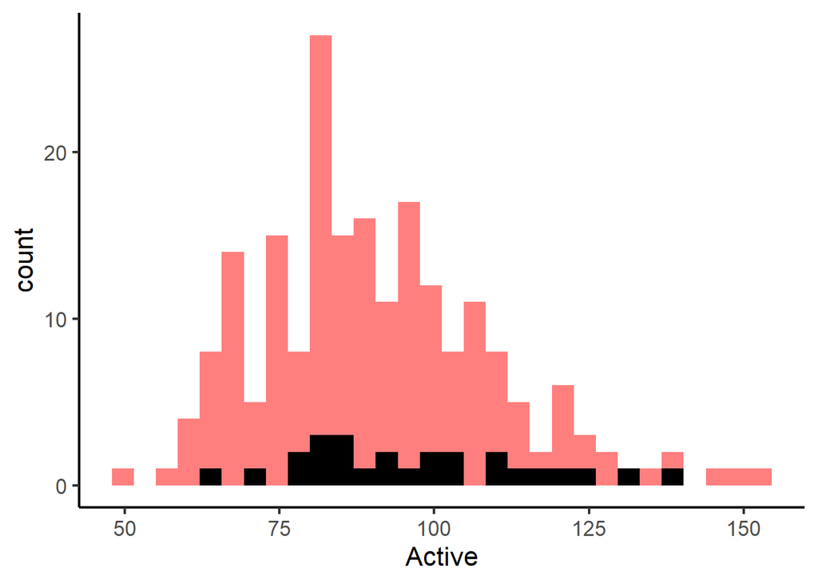

```r
ggplot(data = Pulse_nosmoke,
       aes(x = Active)) +
  geom_histogram(fill = "red",
                 alpha = 0.5,
                 bins = 30) +
  geom_histogram(data = Pulse_smoke,
                 aes(x = Active),
                 fill = "black",
                 bins = 30)
```

- Is active pulse rate **higher** among smokers than non-smokers?

```r
library(BSDA)
ztest1 <- z.test(x = Pulse_smoke$Active,
                y = Pulse_nosmoke$Active,
                sigma.x = sd(Pulse_smoke$Active),
                sigma.y = sd(Pulse_nosmoke$Active),
                alternative = "greater")
ztest1
```

```
    Two-sample z-Test

data:  Pulse_smoke$Active and Pulse_nosmoke$Active
z = 1.7668, p-value = 0.03863
alternative hypothesis: true difference in means is greater than 0
95 percent confidence interval:
 0.4791124        NA
sample estimates:
mean of x mean of y
 97.46154  90.51942
```

```r
ttest1 <- t.test(x = Pulse_smoke$Active,
                y = Pulse_nosmoke$Active,
                alternative = "greater",
                var.equal = TRUE)
ttest1
```

```
    Two Sample t-test

data:  Pulse_smoke$Active and Pulse_nosmoke$Active
t = 1.7806, df = 230, p-value = 0.03815
alternative hypothesis: true difference in means is greater than 0
95 percent confidence interval:
 0.5034263       Inf
sample estimates:
mean of x mean of y
 97.46154  90.51942
```

```r
ttest1b <- t.test(x = Pulse_smoke$Active,
                y = Pulse_nosmoke$Active,
                alternative = "greater",
                var.equal = FALSE)
ttest1b
```

```
    Welch Two Sample t-test

data:  Pulse_smoke$Active and Pulse_nosmoke$Active
t = 1.7668, df = 31.509, p-value = 0.04348
alternative hypothesis: true difference in means is greater than 0
95 percent confidence interval:
 0.2833517       Inf
sample estimates:
mean of x mean of y
 97.46154  90.51942
```

### 3.3 Weight

```r
mean(Pulse_smoke$Wgt)
```

```
[1] 172.0385
```

```r
mean(Pulse_nosmoke$Wgt)
```

```
[1] 156.1359
```

```r
var(Pulse_smoke$Wgt)
```

```
[1] 1347.718
```

```r
var(Pulse_nosmoke$Wgt)
```

```
[1] 948.9961
```

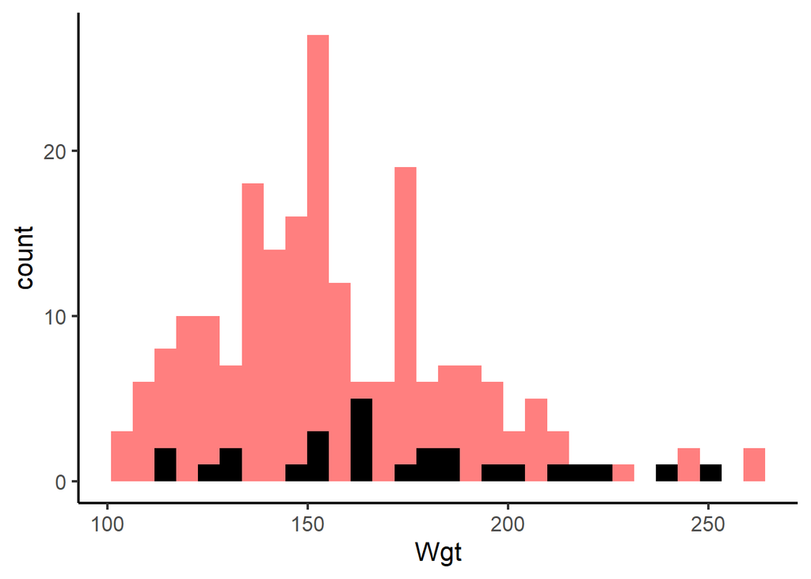

```r
ggplot(data = Pulse_nosmoke,
       aes(x = Wgt)) +
  geom_histogram(fill = "red",
                 alpha = 0.5,
                 bins = 30) +
  geom_histogram(data = Pulse_smoke,
                 aes(x = Wgt),
                 fill = "black",
                 bins = 30)
```

- Do smokers weight **less than** non-smokers?

```r
ztest2 <- z.test(x = Pulse_smoke$Wgt,
                y = Pulse_nosmoke$Wgt,
                sigma.x = sd(Pulse_smoke$Wgt),
                sigma.y = sd(Pulse_nosmoke$Wgt),
                alternative = "less")
ztest2
```

```
    Two-sample z-Test

data:  Pulse_smoke$Wgt and Pulse_nosmoke$Wgt
z = 2.1167, p-value = 0.9829
alternative hypothesis: true difference in means is less than 0
95 percent confidence interval:
       NA 28.25999
sample estimates:
mean of x mean of y
 172.0385  156.1359
```

```r
ttest2 <- t.test(x = Pulse_smoke$Wgt,
                y = Pulse_nosmoke$Wgt,
                alternative = "less",
                var.equal = TRUE)
ttest2
```

```
    Two Sample t-test

data:  Pulse_smoke$Wgt and Pulse_nosmoke$Wgt
t = 2.4256, df = 230, p-value = 0.992
alternative hypothesis: true difference in means is less than 0
95 percent confidence interval:
     -Inf 26.73016
sample estimates:
mean of x mean of y
 172.0385  156.1359
```

```r
ttest2b <- t.test(x = Pulse_smoke$Wgt,
                y = Pulse_nosmoke$Wgt,
                alternative = "less",
                var.equal = FALSE)
ttest2b
```

```
    Welch Two Sample t-test

data:  Pulse_smoke$Wgt and Pulse_nosmoke$Wgt
t = 2.1167, df = 29.613, p-value = 0.9786
alternative hypothesis: true difference in means is less than 0
95 percent confidence interval:
     -Inf 28.65903
sample estimates:
mean of x mean of y
 172.0385  156.1359
```

### 3.4 Exercise

```r
mean(Pulse_smoke$Exercise)
```

```
[1] 1.807692
```

```r
mean(Pulse_nosmoke$Exercise)
```

```
[1] 2.31068
```

```r
var(Pulse_smoke$Exercise)
```

```
[1] 0.4815385
```

```r
var(Pulse_nosmoke$Exercise)
```

```
[1] 0.5273976
```

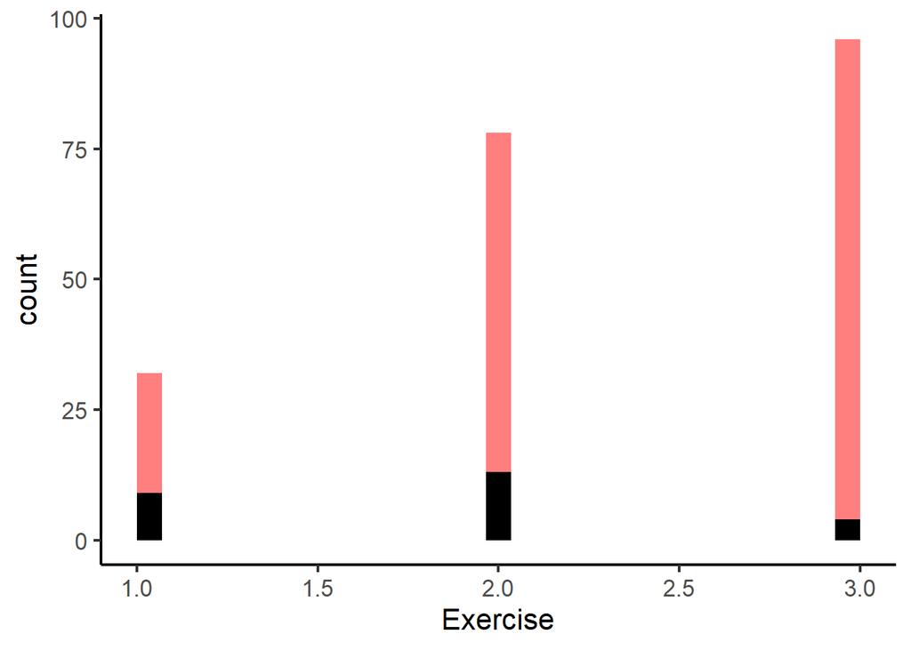

```r
ggplot(data = Pulse_nosmoke,
       aes(x = Exercise)) +
  geom_histogram(fill = "red",
                 alpha = 0.5,
                 bins = 30) +
  geom_histogram(data = Pulse_smoke,
                 aes(x = Exercise),
                 fill = "black",
                 bins = 30)
```

- Do smokers and non-smokers exercise the **same** amount?

```r
ztest3 <- z.test(x = Pulse_smoke$Exercise,
                y = Pulse_nosmoke$Exercise,
                sigma.x = sd(Pulse_smoke$Exercise),
                sigma.y = sd(Pulse_nosmoke$Exercise),
                alternative = "two.sided")
ztest3
```

```
    Two-sample z-Test

data:  Pulse_smoke$Exercise and Pulse_nosmoke$Exercise
z = -3.4643, p-value = 0.0005317
alternative hypothesis: true difference in means is not equal to 0
95 percent confidence interval:
 -0.7875596 -0.2184150
sample estimates:
mean of x mean of y
 1.807692  2.310680
```

```r
ttest3 <- t.test(x = Pulse_smoke$Exercise,
                y = Pulse_nosmoke$Exercise,
                alternative = "two.sided",
                var.equal = TRUE)
ttest3
```

```
    Two Sample t-test

data:  Pulse_smoke$Exercise and Pulse_nosmoke$Exercise
t = -3.3437, df = 230, p-value = 0.0009651
alternative hypothesis: true difference in means is not equal to 0
95 percent confidence interval:
 -0.7993817 -0.2065929
sample estimates:
mean of x mean of y
 1.807692  2.310680
```

```r
ttest3b <- t.test(x = Pulse_smoke$Exercise,
                y = Pulse_nosmoke$Exercise,
                alternative = "two.sided",
                var.equal = FALSE)
ttest3b
```

```
    Welch Two Sample t-test

data:  Pulse_smoke$Exercise and Pulse_nosmoke$Exercise
t = -3.4643, df = 32.314, p-value = 0.001521
alternative hypothesis: true difference in means is not equal to 0
95 percent confidence interval:
 -0.7986223 -0.2073523
sample estimates:
mean of x mean of y
 1.807692  2.310680
```

```r
library(coin)
median_test(Exercise ~ as.factor(Smoke), data = Pulse)
```

```
    Asymptotic Two-Sample Brown-Mood Median Test

data:  Exercise by as.factor(Smoke) (0, 1)
Z = 3.0223, p-value = 0.002509
alternative hypothesis: true mu is not equal to 0
```

```r
wilcox.test(Exercise ~ as.factor(Smoke), data = Pulse)
```

```
    Wilcoxon rank sum test with continuity correction

data:  Exercise by as.factor(Smoke)
W = 3657, p-value = 0.001026
alternative hypothesis: true location shift is not equal to 0
```